# **Programming Assignement 1: Implmenting the Discrete Event Simulator**

### 1.6.2 Event chain structure

Since our simulation processes on event after the other, where the events should be sorted and prioritized, using the heapq is very convinient since it automatically sorts the entries I push into it, i.e. from smallest to biggest item (timestamp attribute - from oldest to newest). Well, it doesnt truly do it automatically, because I had to overload the lt operator, but this is much easier, less work and more efficient (faster) than saving it in a list myself and then writing a sorting algorithm myself.

### 1.6.3 Update event chain

If I had to implement the simulation from scratch, I would have probably chosen to have an event generating routine which are then processed on after the other. The drawback here is, depending on how long the simulatin should span, the number of events could lead to memory inefficiencies and slower overall performance. Also, my implementation could not be easily adapted to a loop implementation, which runs for ever if you dont stop it. Such a loop is always a cool thing for demonstrations, because you could litteraly dile up the arriving packets and than see in real time how your simulation reacts. In my implementation style, I could basically tread the Custumor Arrivals the same since they are independent of the system sate However, the service completion are not independent but the contrary, dependent since I generate a random number for the propcessing time. So what I would have to be to generate the processing before it even gets to be processed, I dont really like that idea.

For these reasons it is much more elegant to insert the events on the fly.

# Simulation Study I

### 1.7.1 Queue length determination

Wow, I needed much longer for this one than I anticipated. Turns out, I have to call sim.reset() each time in the for loop. How could I have not known about this? I dont know, but now it is working in an acceptable from.

When you call the task task_1_7_1() the following program runs. First, all the parameters are initialized. Then my do_simulation_study function is called. It consits of 2 loops, one while loop that runs for ever if not broken, and a for that runs for the sum.sim_param.NO_OF_RUNS specified number of runs. Now, inside of the while loop I initiallize a counter that gets raised inside of the while loop each time a simulation had less than 10 dropped packets. After the for loop is finished, the following fraction is calculated lt_10_pkts_dropped_counter/sim.sim_param.NO_OF_RUNS, if this is bigger than 0.8, the current packet buffer is return, else it gets raised at the beginning of the while loop. With my matricelnumber specified as the seed, this is the result:

```python
from part1_simstudy import *
```

```python
task_1_7_1();
```

```
Buffer Size: 1: Less than 10 packets dropped percentage: 0.0
Buffer Size: 2: Less than 10 packets dropped percentage: 0.046
Buffer Size: 3: Less than 10 packets dropped percentage: 0.319
Buffer Size: 4: Less than 10 packets dropped percentage: 0.543
Buffer Size: 5: Less than 10 packets dropped percentage: 0.683
Buffer Size: 6: Less than 10 packets dropped percentage: 0.782
Buffer Size: 7: Less than 10 packets dropped percentage: 0.837
Minimal buffer Size: 7
```

### 1.7.2 Queue Length Determination II

I need to be careful. The problem statement does not tell me that the simulation runs are decreased and the time increased. So we kind of now have the 2 cases:

1. SIM_TIME=100s and NO_OF_RUNS=1000
2. SIM_TIME=1000s and NO_OF_RUNS=100

So, multipyling the 2 leads to the same number, but that does not mean the result is the same. As can be seen from my code, the returned buffer sizes changes.

```python
task_1_7_2();
```

```
Buffer Size: 1: Less than 10 packets dropped percentage: 0.0
Buffer Size: 2: Less than 10 packets dropped percentage: 0.0
Buffer Size: 3: Less than 10 packets dropped percentage: 0.025
Buffer Size: 4: Less than 10 packets dropped percentage: 0.419
Buffer Size: 5: Less than 10 packets dropped percentage: 0.761
Buffer Size: 6: Less than 10 packets dropped percentage: 0.887
Minimal buffer Size: 6
```

### 1.7.3 Comparison of Results

The plot below shows that not every line looks alike, they are only similar. The longer the simulation time is set, the "sloppier" the plotted curves become. This means, the longer simulation times hand me a more accurate buffer size at which the system is capable of operating. Hence, the longer I sumulate, the better my understanding of the system becomes.

```
Finished with SIm 1
Finished with SIm 2
Finished with SIm 3
```

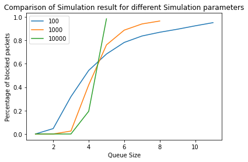

```
Finished...
```

```
True
```

```python
task_1_7_3()
```